# Práctica entregable: Segmentación de imaxes con Deep Learning

Notas importantes para a entrega: teredes que entregar un arquivo comprimido en formato .zip co formato `Apelidos_Nome_P5.zip` (sen acentos nin caracteres especiais, p.ex., PerezGarcia_Juan_P5.zip), que conterá dous arquivos.

- Este Jupyter Notebook cos exercicios resoltos e todas as celdas executadas (de tal maneira que se poidan ver os resultados), que terá o nome `Apelidos_Nome_P5.ipynb`
- O mesmo notebook exportado a HTML, co nome `Apelidos_Nome_P5.html`. Do mesmo xeito, deberedes ter todas as celdas executadas antes de exportalo, para que se poidan ver os resultados.

Nesta práctica imos traballar directamente con modelos de Deep Learning orientados á segmentación de imaxes, utilizando distintas arquitecturas do estado da arte. Dado que o adestramento destes sistemas pode ser computacionalmente intensivo, recoméndase empregar Google Colab ou, de non ser suficiente, o clúster de computación do CESGA.

O conxunto de datos que empregaremos será de novo o *FruitSeg30*, que xa utilizamos na práctica anterior. Se non o fixeches, descarga e descomprime dito conxunto executando a celda seguinte:

```python
from pathlib import Path
import zipfile
from urllib import request

import torch
from torch import nn
from torchvision.transforms import functional as TF
```

```python
url = 'https://prod-dcd-datasets-cache-zipfiles.s3.eu-west-1.amazonaws.com/vkht8pfsp3-3.zip'
dataset_name = Path('FruitSeg30_Segmentation Dataset & Mask Annotations')
output_zip_path = Path('FruitSeg30.zip')
dataset_dir = Path('FruitSeg30')

if not dataset_dir.is_dir():
    request.urlretrieve(url, output_zip_path)
    with zipfile.ZipFile(output_zip_path, 'r') as zip_ref:
        zip_ref.extractall()

    (dataset_name/dataset_dir).rename(dataset_dir)

    output_zip_path.unlink()
    dataset_name.rmdir()
```

```python
!git clone https://github.com/mateofra/VPC_
```

```
Cloning into 'VPC_'...
remote: Enumerating objects: 4243, done.
remote: Counting objects: 100% (5/5), done.
remote: Compressing objects: 100% (4/4), done.
remote: Total 4243 (delta 1), reused 4 (delta 1), pack-reused 4238 (from 1)
Receiving objects: 100% (4243/4243), 548.22 MiB | 40.72 MiB/s, done.
Resolving deltas: 100% (12/12), done.
Updating files: 100% (4245/4245), done.
```

```python
%cd VPC_/Practicassss
```

```
/content/VPC_/Practicassss
```

## Arquitectura U-Net

A rede U-Net é unha arquitectura de rede neuronal convolucional deseñada para tarefas de segmentación de imaxes, inicialmente desenvolvida para segmentación biomédica. A súa estrutura ten forma de "U", estando composta por unha parte de contracción (encoder) e unha parte de expansión (decoder). Debaixo podes ver un esquema da arquitectura orixinal proposta no 2015 por Olaf Ronneberger et al. no artigo ["U-Net: Convolutional Networks for Biomedical Image Segmentation"](https://arxiv.org/abs/1505.04597).

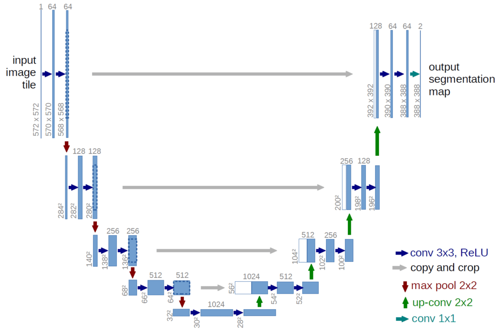

A parte do codificador segue unha estrutura convencional de rede neuronal convolucional (CNN) para extraer características relevantes das imaxes de entrada. A imaxe de entrada é procesada en bloques, onde se lle aplican dúas capas convolucionais seguidas dunha capa de *pooling* para reducir a dimensión espacial das características extraídas. Cada capa convolucional utiliza un tamaño de filtro de 3x3 e unha función de activación ReLU para introducir non linealidade no modelo. A capa de *pooling* emprega unha operación de max-pooling con un tamaño de 2x2 para reducir a resolución das características, o que axuda a diminuír o número de parámetros e a evitar o sobreaxuste. Ao igual que nunha CNN básica, o número de filtros nas capas convolucionais duplícase por dous despois de cada capa de *pooling*, permitindo á rede capturar características máis complexas a medida que avanza.

A parte do decodificador segue unha estrutura simétrica á do codificador. As características obtidas do codificador son procesadas en bloques, onde se lle aplican un *upsampling* para aumentar a resolución seguido de dúas capas convolucionais. Cada capa convolucional tamén utiliza un tamaño de filtro de 3x3 e unha función de activación ReLU. Dependendo da implementación, as capa de *upsampling* consisten nunha operación de reescalado sinxela (utilizando interpolación) ou unha convolución trasposta. Neste caso, o número de filtros nas capas convolucionais do decodificador redúcese á metade despois de cada operación de *upsampling*, restaurando gradualmente a resolución orixinal da imaxe de entrada.

É tamén relevante que en cada nivel de profundidade da rede, as características do codificador son concatenadas coas características correspondentes do decodificador. Esta técnica, coñecida como "skip connections" ou conexións de salto, axuda a preservar a información espacial e os detalles finos da imaxe orixinal, facilitando unha mellor reconstrucción da imaxe de saída.

A continuación amósase un exemplo de código en Pytorch que implementa esta arquitectura:

```python
class UNet(nn.Module):
    def __init__(self, in_channels=3, out_channels=1, features=[64, 128, 256, 512]):
        super(UNet, self).__init__()
        self.encoder = nn.ModuleList()
        self.decoder = nn.ModuleList()
        # Encoder
        for feature in features:
            self.encoder.append(self.conv_block(in_channels, feature))
            in_channels = feature
        # Decoder
        for feature in reversed(features):
            self.decoder.append(
                nn.ConvTranspose2d(feature*2, feature, kernel_size=2, stride=2)
            )
            self.decoder.append(self.conv_block(feature*2, feature))
        self.bottleneck = self.conv_block(features[-1], features[-1]*2)
        self.final_conv = nn.Conv2d(features[0], out_channels, kernel_size=1)

    def conv_block(self, in_channels, out_channels):
        return nn.Sequential(
            nn.Conv2d(in_channels, out_channels, kernel_size=3, padding=1),
            nn.ReLU(inplace=True),
            nn.Conv2d(out_channels, out_channels, kernel_size=3, padding=1),
            nn.ReLU(inplace=True),
        )

    def forward(self, x):
        skip_connections = []
        for layer in self.encoder:
            x = layer(x)
            skip_connections.append(x)
            x = nn.MaxPool2d(kernel_size=2)(x)
        x = self.bottleneck(x)
        skip_connections = skip_connections[::-1]
        for idx in range(0, len(self.decoder), 2):
            x = self.decoder[idx](x)
            skip_connection = skip_connections[idx//2]
            if x.shape != skip_connection.shape:
                x = TF.resize(x, size=skip_connection.shape[2:])
            x = torch.cat((skip_connection, x), dim=1)
            x = self.decoder[idx+1](x)
        return self.final_conv(x)
```

## Exercicio proposto

1. Crea un dataset xenérico (mediante unha clase que herde de `torch.utils.data.Dataset`). O constructor debe recibr como parámetro os directorios das imaxes e das máscaras, por exemplo `FruitSeg30/Apple_Gala/Images` e `FruitSeg30/Apple_Gala/Mask`. Este clase debe implementar ademáis os métodos `__len__` e `__getitem__`, de xeito que o primeiro devolva o número de imaxes no conxunto de datos, e o segundo devolva unha tupla `(imaxe, máscara)` para o índice dado. Para cargar as imaxes e máscaras, podes empregar a biblioteca `PIL`. Logo de cargar a imaxe e a máscara, aplícalles as transformacións necesarias para devolvelas como obxectos da clase `torch.Tensor` e cun tamaño de 128x128.
2. Crea os obxectos `Dataset` e `DataLoader` necesarios para cargar o conxunto de datos de imaxes e máscaras de segmentación. Deberás obter un dicionario no que as chaves sexan as categorías (`Apple_Gala`, `Apple_Golden Delicious`, etc.), e os valores sexan á súa vez dicionarios cuxas chaves serán `dataset_train`, `dataset_val`, `dataset_test`, `dataloader_train`, `dataloader_val` e `dataloader_test`. Utiliza un tamaño de lote de 4 para o `Dataloader` de adestramento (os de validación e test poden levar calquera tamaño de lote) e un split aleatorio de 60%/20%/20% para a división entre conxuntos de adestramento, validación e test.

   Exemplo:

   ```
   {
       'Apple_Gala': {
           'dataset_train': <Dataset object>,
           'dataset_val': <Dataset object>,
           'dataset_test': <Dataset object>,
           'dataloader_train': <DataLoader object>,
           'dataloader_val': <DataLoader object>,
           'dataloader_test': <DataLoader object>,
       },
       'Apple_Golden Delicious': {
           ...
       },
       ...
   }
   ```

3. Proba os modelos de segmentación DeepLabV3 e FCN, do paquete `torchvision.models.segmentation`, e a implementación da UNet proposta nesta práctica. Ten en conta o seguinte:
- Utiliza os `DataLoader` creados no exercicio anterior para adestrar e validar os modelos.
- Emprega como función de perda a entropía cruzada binaria, e como optimizador `Adam`.
- Adestra os modelos utilizando *early stopping* para evitar o sobreaxuste, é dicir, para o adestramento cando a perda obtida no conxunto de validación non mellore durante un número determinado de épocas. Quédate co modelo que obteña a mellor perda no conxunto de validación.
- Obtén as métricas Dice e Hausdorff no conxunto de test para cada modelo e cada categoría (se o adestramento consume moito tempo podes seleccionar un subconxunto de categorías, como mínimo 3). Compara os resultados obtidos cos distintos modelos, incluíndo na comparativa o número de parámetros de cada modelo.
- Xera visualizacións dos resultados obtidos. Para cada modelo e categoría, amosa o resultado da segmentación no mellor e no peor caso, utilizando a visualización TP, TN, FP e FN que se explicou na práctica anterior.
- Xustifica se as predicións se poderían mellorar empregando operacións morfolóxicas de postprocesado.
4. Contesta ás seguintes preguntas sobre a arquitectura UNet:
- Que cambios habería que facer na implementación da UNet para aumentar o número de niveis de profundidade?
- Poderíamos aumentar indefinidamente o número de niveis de profundidade da UNet ou existe algunha limitación?
- Se aumentamos o tamaño das imaxes de entrada, seguiría funcionando a implementación actual da UNet?

## Clase Dataset

```python
from torch.utils.data import Dataset, DataLoader
from PIL import Image #cargar as imaxes
import os

import torchvision.transforms as T

class SegmentationDataset(Dataset):
    def __init__(self, img_dir, masks_dir, size=128):
        self.imagenes_dir = img_dir
        self.masks_dir = masks_dir
        self.imagenes = sorted([f for f in os.listdir(self.imagenes_dir) if f.lower().endswith(('.jpg', '.png', '.jpeg'))])
        self.masks = sorted([f for f in os.listdir(self.masks_dir) if f.lower().endswith(('.jpg', '.png', '.jpeg'))])
        self.transform_img = T.Compose([
            T.Resize((size, size)),
            T.ToTensor(),
        ])
        self.transform_mask = T.Compose([
            T.Resize((size, size), interpolation=Image.NEAREST),
            T.ToTensor(),
        ])

    def __len__(self): # numero de imaxes no conxunto de datos
        return len(self.imagenes)

    def __getitem__(self, idx): # Imaxe e máscara a apartir do índice
        ruta_img = os.path.join(self.imagenes_dir, self.imagenes[idx])
        ruta_mask = os.path.join(self.masks_dir, self.masks[idx])
        imagen = Image.open(ruta_img).convert('RGB')
        mask = Image.open(ruta_mask).convert('L')
        imagen = self.transform_img(imagen)
        mask = self.transform_mask(mask)
        mask = (mask > 0.5).float() # binarizar máscara
        return imagen, mask
```

```python
from sklearn.model_selection import train_test_split

directorios = [d.name for d in dataset_dir.iterdir() if d.is_dir()]
data_dicc = {}

class SubsetDS(SegmentationDataset): #copia parte do dataset
    def __init__(self, img_dir, masks_dir, indices, size=128):
        super().__init__(img_dir, masks_dir, size)
        self.indices = indices
    def __len__(self):
        return len(self.indices) #solo o número de índices no subconxunto
    def __getitem__(self, idx):
        return super().__getitem__(self.indices[idx]) #obtemos o elemento do índice orixinal

def subset_dataset(indices, img_dir, mask_dir):
    return SubsetDS(img_dir, mask_dir, indices)

for dir in directorios:
    img_dir = dataset_dir / dir / 'Images'
    mask_dir = dataset_dir / dir / 'Mask'
    imagenes = sorted([f for f in os.listdir(img_dir) if f.lower().endswith(('.jpg', '.png', '.jpeg'))])
    idxs = list(range(len(imagenes)))
    #Split 60% train, 20% val, 20% test
    train_idx, temp_idx = train_test_split(idxs, test_size=0.4, random_state=42)
    val_idx, test_idx = train_test_split(temp_idx, test_size=0.5, random_state=42)

    ds_train = subset_dataset(train_idx, img_dir, mask_dir)
    ds_val = subset_dataset(val_idx, img_dir, mask_dir)
    ds_test = subset_dataset(test_idx, img_dir, mask_dir)

    data_dicc[dir] = {
        'dataset_train': ds_train,
        'dataset_val': ds_val,
        'dataset_test': ds_test,
        'dataloader_train': DataLoader(ds_train, batch_size=4, shuffle=True, drop_last=True),
        'dataloader_val': DataLoader(ds_val, batch_size=8, shuffle=False),
        'dataloader_test': DataLoader(ds_test, batch_size=8, shuffle=False),
    }
```

```python
import torch
import torch.nn as nn
import torch.optim as optim
from torchvision.models.segmentation import fcn_resnet50, deeplabv3_resnet50
import numpy as np
from tqdm.notebook import tqdm
import matplotlib.pyplot as plt
from scipy.spatial.distance import directed_hausdorff


# --- Funciones para Métricas ---
# 2*|X interseccion Y| / (|X| + |Y|)
def dice_coefficient(pred, target, smooth=1e-6):
    pred = torch.sigmoid(pred) > 0.5
    pred_flat = pred.contiguous().view(-1)
    target_flat = target.contiguous().view(-1)
    intersection = (pred_flat * target_flat).sum()
    dice = (2. * intersection + smooth) / (pred_flat.sum() + target_flat.sum() + smooth)
    return dice.item()

# max{sup d(x,Y), sup d(X,y)}
def hausdorff_distance(pred, target):
    pred_coords = np.transpose(np.nonzero(pred.squeeze().cpu().numpy()))
    target_coords = np.transpose(np.nonzero(target.squeeze().cpu().numpy()))

    # La distancia de Hausdorff no está definida si un conjunto está vacío
    if len(pred_coords) == 0 or len(target_coords) == 0:
        return float('inf') # O un valor alto predefinido

    # Calcular la distancia de Hausdorff dirigida en ambas direcciones y tomar el máximo
    h1 = directed_hausdorff(pred_coords, target_coords)[0]
    h2 = directed_hausdorff(target_coords, pred_coords)[0]
    return max(h1, h2)


# --- Función de Entrenamiento y Validación con Early Stopping ---

def adestrar_modelo(modelo, dataloaders, criterion, optimizer, device, num_epocas=25, patience=5):

    modelo.to(device)
    mejor_perdida_validacion = float('inf')
    paciencia = 0
    mellor_estado = None

    for epoca in range(num_epocas):

        # Fase de entrenamiento
        modelo.train()
        perdida_adestramento = 0.0

        for inputs, masks in dataloaders['dataloader_train']:

            inputs, masks = inputs.to(device), masks.to(device)

            optimizer.zero_grad()
            outputs = modelo(inputs)
            # torchvision devolven un dict, a UNet non
            if isinstance(outputs, dict):
                outputs = outputs['out']

            perdida = criterion(outputs, masks)
            perdida.backward()
            optimizer.step()
            perdida_adestramento += perdida.item() * inputs.size(0)

        perdida_epoca = perdida_adestramento / len(dataloaders['dataset_train'])

        # Fase de validación
        modelo.eval()
        perdida_validacion = 0.0
        with torch.no_grad():
            for inputs, masks in dataloaders['dataloader_val']:
                inputs, masks = inputs.to(device), masks.to(device)
                outputs = modelo(inputs)
                if isinstance(outputs, dict):
                    outputs = outputs['out']
                loss = criterion(outputs, masks)
                perdida_validacion += loss.item() * inputs.size(0)

        perdida_validacion /= len(dataloaders['dataset_val'])
        print(f'Época {epoca+1}/{num_epocas}, Train Loss: {perdida_epoca:.4f}, Val Loss: {perdida_validacion:.4f}')

        # Lóxica de Early Stopping
        if perdida_validacion < mejor_perdida_validacion:
            mejor_perdida_validacion = perdida_validacion
            paciencia = 0
            mellor_estado = modelo.state_dict()
        else:
            paciencia += 1
            if paciencia >= patience:
                print(f'Early stopping na época {epoca+1}')
                break

    #  mellor modelo
    modelo.load_state_dict(mellor_estado)
    return modelo

# --- Función de Evaluación en el conjunto de Test ---

def evaluar_modelo(modelo, dataloader_test, device):
    modelo.eval()
    modelo.to(device)
    metrica_dice = []
    metrica_hausdorff = []

    mellor_caso = {'score': -1, 'data': None}
    peor_caso = {'score': 2, 'data': None} # Dice va de 0 a 1

    with torch.no_grad():
        for inputs, masks in dataloader_test:
            inputs, masks = inputs.to(device), masks.to(device)
            outputs = modelo(inputs)
            if isinstance(outputs, dict):
                outputs = outputs['out']

            # Iterar sobre cada imaxe
            for j in range(inputs.size(0)):

                pred = torch.sigmoid(outputs[j]) > 0.5
                mask = masks[j]

                dice = dice_coefficient(outputs[j], mask)
                hd = hausdorff_distance(pred, mask)

                metrica_dice.append(dice)
                if hd != float('inf'): #só distancias válidas!!
                    metrica_hausdorff.append(hd)

                # Gardar casos (basados en Dice)
                if dice > mellor_caso['score']:
                    mellor_caso['score'] = dice
                    mellor_caso['data'] = (inputs[j].cpu(), mask.cpu(), pred.cpu())
                if dice < peor_caso['score']:
                    peor_caso['score'] = dice
                    peor_caso['data'] = (inputs[j].cpu(), mask.cpu(), pred.cpu())

    dice_promedio = np.mean(metrica_dice)
    hd_promedio = np.mean(metrica_hausdorff) if metrica_hausdorff else float('nan')

    return dice_promedio, hd_promedio, mellor_caso, peor_caso

# --- Función de Visualización ---
def resultados(imaxe, true_mask, pred_mask, title):
    true_mask = true_mask.squeeze().numpy()
    pred_mask = pred_mask.squeeze().numpy()

    # Calcular TP, FP, FN, TN
    tp = np.logical_and(true_mask, pred_mask)
    fp = np.logical_and(np.logical_not(true_mask), pred_mask)
    fn = np.logical_and(true_mask, np.logical_not(pred_mask))

    #  imaxen de visualización
    overlay = np.zeros((imaxe.shape[1], imaxe.shape[2], 3), dtype=np.uint8)
    overlay[tp] = [255, 255, 255]  # Blanco (TP)
    overlay[fp] = [255, 0, 0]    # Rojo (FP)
    overlay[fn] = [0, 0, 255]    # Azul (FN)

    fig, axes = plt.subplots(1, 4, figsize=(20, 5))
    fig.suptitle(title, fontsize=16)

    axes[0].imshow(imaxe.permute(1, 2, 0))
    axes[0].set_title("Imagen Original")
    axes[0].axis('off')

    axes[1].imshow(true_mask, cmap='gray')
    axes[1].set_title("Máscara Real (Ground Truth)")
    axes[1].axis('off')

    axes[2].imshow(pred_mask, cmap='gray')
    axes[2].set_title("Máscara Predicha")
    axes[2].axis('off')

    axes[3].imshow(overlay)
    axes[3].set_title("Visualización (TP: Blanco, FP: Rojo, FN: Azul)")
    axes[3].axis('off')

    plt.show()
```

```
Usando dispositivo: cuda
--- PROCESANDO CATEGORÍA: Apple_Gala ---

--- Entrenando modelo: UNet ---
Época 1/30, Train Loss: 0.6130, Val Loss: 0.6507
Época 2/30, Train Loss: 0.5778, Val Loss: 0.5980
Época 3/30, Train Loss: 0.5293, Val Loss: 0.5582
Época 4/30, Train Loss: 0.4993, Val Loss: 0.5145
Época 5/30, Train Loss: 0.4481, Val Loss: 0.4377
Época 6/30, Train Loss: 0.4186, Val Loss: 0.3932
Época 7/30, Train Loss: 0.4119, Val Loss: 0.3797
Época 8/30, Train Loss: 0.3862, Val Loss: 0.3825
Época 9/30, Train Loss: 0.3806, Val Loss: 0.3819
Época 10/30, Train Loss: 0.3769, Val Loss: 0.4060
Época 11/30, Train Loss: 0.3574, Val Loss: 0.3304
Época 12/30, Train Loss: 0.3306, Val Loss: 0.3110
Época 13/30, Train Loss: 0.3194, Val Loss: 0.2836
Época 14/30, Train Loss: 0.2941, Val Loss: 0.2525
Época 15/30, Train Loss: 0.2658, Val Loss: 0.2360
Época 16/30, Train Loss: 0.2559, Val Loss: 0.2619
Época 17/30, Train Loss: 0.2866, Val Loss: 0.3600
Época 18/30, Train Loss: 0.2948, Val Loss: 0.2416
Época 19/30, Train Loss: 0.2472, Val Loss: 0.2183
Época 20/30, Train Loss: 0.2363, Val Loss: 0.2143
Época 21/30, Train Loss: 0.2372, Val Loss: 0.2222
Época 22/30, Train Loss: 0.2245, Val Loss: 0.2301
Época 23/30, Train Loss: 0.2395, Val Loss: 0.2214
Época 24/30, Train Loss: 0.2317, Val Loss: 0.2185
Época 25/30, Train Loss: 0.2152, Val Loss: 0.2132
Época 26/30, Train Loss: 0.2263, Val Loss: 0.2166
Época 27/30, Train Loss: 0.2275, Val Loss: 0.1989
Época 28/30, Train Loss: 0.2188, Val Loss: 0.2773
Época 29/30, Train Loss: 0.2355, Val Loss: 0.2280
Época 30/30, Train Loss: 0.2302, Val Loss: 0.1973

Resultados para UNet en Apple_Gala:
  - Parámetros: 31.03M
  - Dice promedio (test): 0.8275
  - Hausdorff promedio (test): 14.6425

Visualizando mejor caso...
```

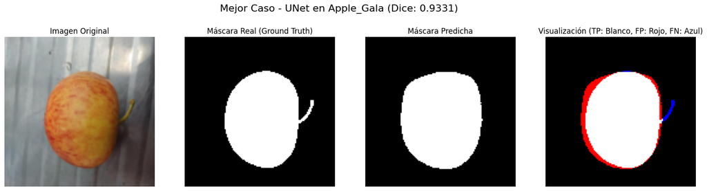

```
Visualizando peor caso...
```

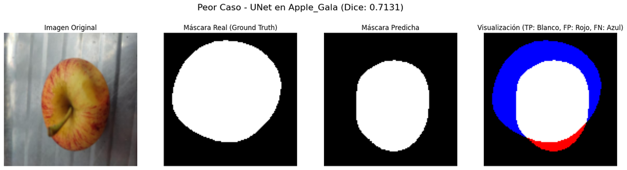

```
--- Entrenando modelo: FCN_ResNet50 ---
Época 1/30, Train Loss: 0.3637, Val Loss: 0.3510
Época 2/30, Train Loss: 0.2488, Val Loss: 0.4465
Época 3/30, Train Loss: 0.1974, Val Loss: 0.3362
Época 4/30, Train Loss: 0.1483, Val Loss: 0.2823
Época 5/30, Train Loss: 0.1358, Val Loss: 0.2327
Época 6/30, Train Loss: 0.1073, Val Loss: 0.2189
Época 7/30, Train Loss: 0.0933, Val Loss: 0.2577
Época 8/30, Train Loss: 0.0865, Val Loss: 0.2436
Época 9/30, Train Loss: 0.0822, Val Loss: 0.2370
Época 10/30, Train Loss: 0.0798, Val Loss: 0.2549
Época 11/30, Train Loss: 0.0733, Val Loss: 0.2440
Early stopping na época 11

Resultados para FCN_ResNet50 en Apple_Gala:
  - Parámetros: 32.95M
  - Dice promedio (test): 0.8221
  - Hausdorff promedio (test): 14.8880

Visualizando mejor caso...
```

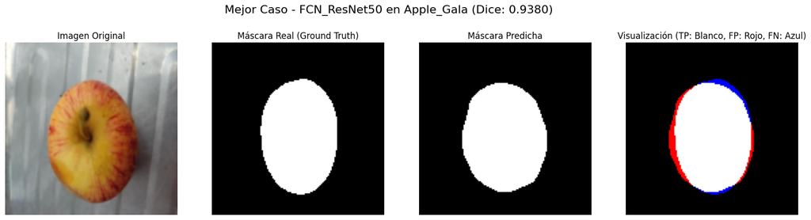

```
Visualizando peor caso...
```

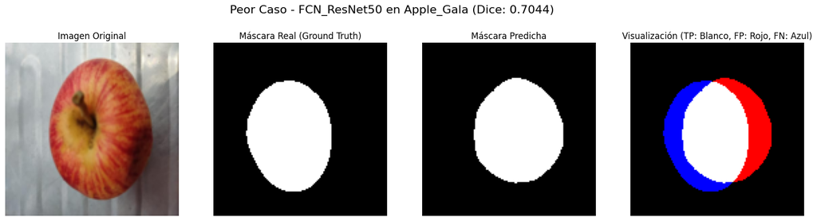

```
--- Entrenando modelo: DeepLabV3_ResNet50 ---
Época 1/30, Train Loss: 0.3994, Val Loss: 0.5564
Época 2/30, Train Loss: 0.2546, Val Loss: 0.3842
Época 3/30, Train Loss: 0.1832, Val Loss: 0.2966
Época 4/30, Train Loss: 0.1606, Val Loss: 0.2730
Época 5/30, Train Loss: 0.1357, Val Loss: 0.2541
Época 6/30, Train Loss: 0.1273, Val Loss: 0.2569
Época 7/30, Train Loss: 0.1140, Val Loss: 0.2387
Época 8/30, Train Loss: 0.1091, Val Loss: 0.2506
Época 9/30, Train Loss: 0.1001, Val Loss: 0.2579
Época 10/30, Train Loss: 0.1002, Val Loss: 0.2444
Época 11/30, Train Loss: 0.1000, Val Loss: 0.2529
Época 12/30, Train Loss: 0.0926, Val Loss: 0.2478
Early stopping na época 12

Resultados para DeepLabV3_ResNet50 en Apple_Gala:
  - Parámetros: 39.63M
  - Dice promedio (test): 0.8389
  - Hausdorff promedio (test): 13.7910

Visualizando mejor caso...
```

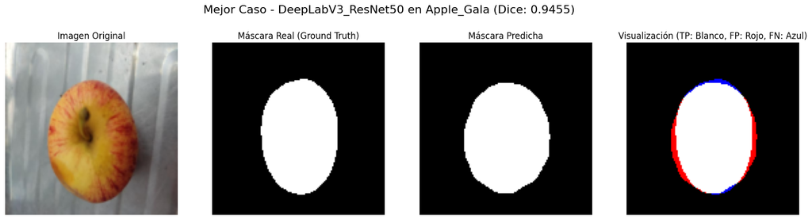

```
Visualizando peor caso...
```

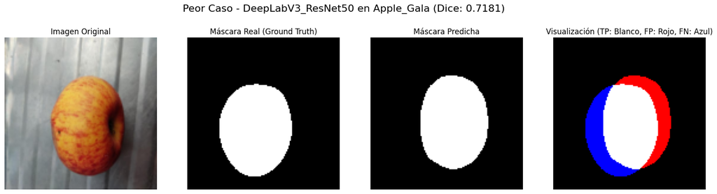

```
--- PROCESANDO CATEGORÍA: Banana ---

--- Entrenando modelo: UNet ---
Época 1/30, Train Loss: 0.4942, Val Loss: 0.4805
Época 2/30, Train Loss: 0.4529, Val Loss: 0.4684
Época 3/30, Train Loss: 0.4400, Val Loss: 0.4463
Época 4/30, Train Loss: 0.4270, Val Loss: 0.4490
Época 5/30, Train Loss: 0.4312, Val Loss: 0.4860
Época 6/30, Train Loss: 0.4272, Val Loss: 0.4489
Época 7/30, Train Loss: 0.4155, Val Loss: 0.4555
Época 8/30, Train Loss: 0.4149, Val Loss: 0.4492
Early stopping na época 8

Resultados para UNet en Banana:
  - Parámetros: 31.03M
  - Dice promedio (test): 0.6814
  - Hausdorff promedio (test): 29.2391

Visualizando mejor caso...
```

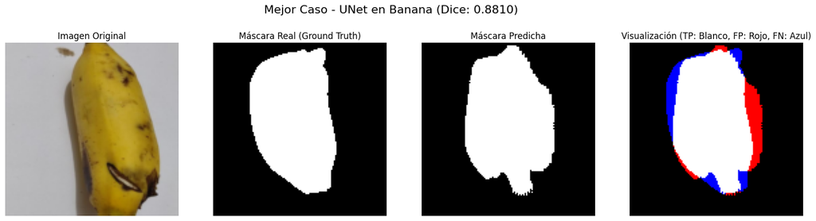

```
Visualizando peor caso...
```

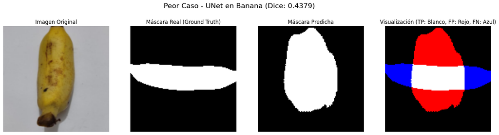

```
--- Entrenando modelo: FCN_ResNet50 ---
Época 1/30, Train Loss: 0.7002, Val Loss: 1.5982
Época 2/30, Train Loss: 0.3629, Val Loss: 0.5200
Época 3/30, Train Loss: 0.3116, Val Loss: 0.4668
Época 4/30, Train Loss: 0.2501, Val Loss: 0.4864
Época 5/30, Train Loss: 0.2003, Val Loss: 0.5248
Época 6/30, Train Loss: 0.1865, Val Loss: 0.5566
Época 7/30, Train Loss: 0.1677, Val Loss: 0.6138
Época 8/30, Train Loss: 0.1662, Val Loss: 0.5965
Early stopping na época 8

Resultados para FCN_ResNet50 en Banana:
  - Parámetros: 32.95M
  - Dice promedio (test): 0.5722
  - Hausdorff promedio (test): 36.9023

Visualizando mejor caso...
```

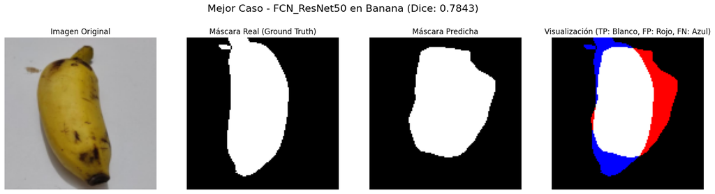

```
Visualizando peor caso...
```

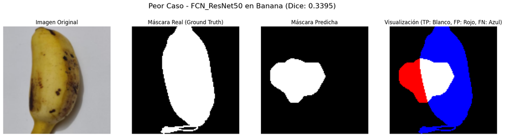

```
--- Entrenando modelo: DeepLabV3_ResNet50 ---
Época 1/30, Train Loss: 0.5972, Val Loss: 0.5342
Época 2/30, Train Loss: 0.3792, Val Loss: 0.5102
Época 3/30, Train Loss: 0.3013, Val Loss: 0.5289
Época 4/30, Train Loss: 0.2452, Val Loss: 0.5733
Época 5/30, Train Loss: 0.2177, Val Loss: 0.6352
Época 6/30, Train Loss: 0.1805, Val Loss: 0.6501
Época 7/30, Train Loss: 0.1656, Val Loss: 0.7093
Early stopping na época 7

Resultados para DeepLabV3_ResNet50 en Banana:
  - Parámetros: 39.63M
  - Dice promedio (test): 0.5742
  - Hausdorff promedio (test): 37.1781

Visualizando mejor caso...
```

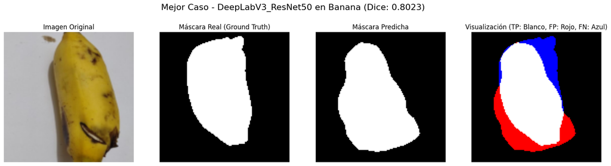

```
Visualizando peor caso...
```

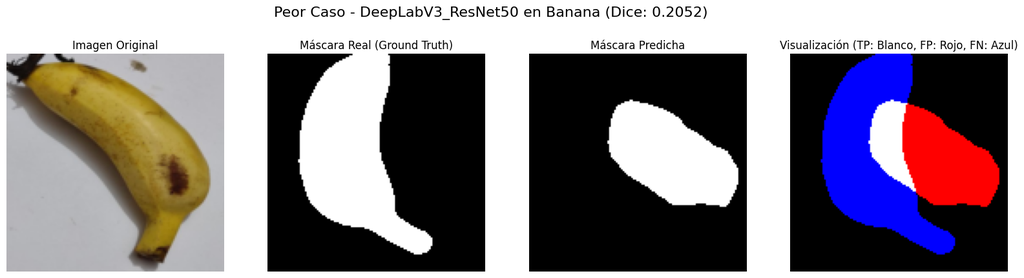

```
--- PROCESANDO CATEGORÍA: Orange ---

--- Entrenando modelo: UNet ---
Época 1/30, Train Loss: 0.3047, Val Loss: 0.3107
Época 2/30, Train Loss: 0.2678, Val Loss: 0.3060
Época 3/30, Train Loss: 0.2577, Val Loss: 0.2843
Época 4/30, Train Loss: 0.2607, Val Loss: 0.3072
Época 5/30, Train Loss: 0.2490, Val Loss: 0.3181
Época 6/30, Train Loss: 0.2625, Val Loss: 0.2792
Época 7/30, Train Loss: 0.2423, Val Loss: 0.2832
Época 8/30, Train Loss: 0.2362, Val Loss: 0.2780
Época 9/30, Train Loss: 0.2346, Val Loss: 0.2922
Época 10/30, Train Loss: 0.2299, Val Loss: 0.2964
Época 11/30, Train Loss: 0.2330, Val Loss: 0.3182
Época 12/30, Train Loss: 0.2416, Val Loss: 0.3043
Época 13/30, Train Loss: 0.2332, Val Loss: 0.2864
Early stopping na época 13

Resultados para UNet en Orange:
  - Parámetros: 31.03M
  - Dice promedio (test): 0.8311
  - Hausdorff promedio (test): 18.9694

Visualizando mejor caso...
```

[6 more figures not shown]

```python
# --- Configuración del Experimento ---
device = torch.device('cuda' if torch.cuda.is_available() else 'cpu')
print(f"Usando dispositivo: {device}")

# Seleccionar un subconjunto de categorías para probar
categories_to_test = ['Apple_Gala', 'Banana', 'Orange']

# Definir los modelos a probar
modelos_to_test = {
    "UNet": UNet(in_channels=3, out_channels=1),
    "FCN_ResNet50": fcn_resnet50(weights=None, num_classes=1),
    "DeepLabV3_ResNet50": deeplabv3_resnet50(weights=None, num_classes=1)
}

results = {}

# --- Bucle Principal ---
for category in categories_to_test:
    print(f"--- PROCESANDO CATEGORÍA: {category} ---")
    results[category] = {}
    dataloaders = data_dicc[category]

    for modelo_nome, modelo in modelos_to_test.items():
        print(f"\n--- Entrenando modelo: {modelo_nome} ---")

        # Contar parámetros del modelo
        num_params = sum(p.numel() for p in modelo.parameters() if p.requires_grad)

        # Configurar optimizador y función de pérdida
        # Usamos BCEWithLogitsLoss porque es más estable numéricamente que Sigmoid + BCELoss
        criterion = nn.BCEWithLogitsLoss()
        optimizer = optim.Adam(modelo.parameters(), lr=1e-4)

        # Entrenar el modelo
        trained_modelo = adestrar_modelo(modelo, dataloaders, criterion, optimizer, device, num_epocas=30, patience=5)

        # Evaluar el modelo
        avg_dice, avg_hausdorff, mellor_caso, peor_caso = evaluar_modelo(trained_modelo, dataloaders['dataloader_test'], device)

        # Guardar resultados
        results[category][modelo_nome] = {
            "params": f"{num_params/1e6:.2f}M",
            "avg_dice": avg_dice,
            "avg_hausdorff": avg_hausdorff
        }

        print(f"\nResultados para {modelo_nome} en {category}:")
        print(f"  - Parámetros: {results[category][modelo_nome]['params']}")
        print(f"  - Dice promedio (test): {avg_dice:.4f}")
        print(f"  - Hausdorff promedio (test): {avg_hausdorff:.4f}")

        # Visualizar mejor y peor caso
        print("\nVisualizando mejor caso...")
        resultados(*mellor_caso['data'], title=f"Mejor Caso - {modelo_nome} en {category} (Dice: {mellor_caso['score']:.4f})")

        print("\nVisualizando peor caso...")
        resultados(*peor_caso['data'], title=f"Peor Caso - {modelo_nome} en {category} (Dice: {peor_caso['score']:.4f})")
```